# 데이터분석 프로젝트 한국인의 삶을 파악하라

한국 복지패널 데이터를 사용한다. - SPSS 형태로 되어 있으므로 foreign 패키지와 시각화패키지들이 필요하다.

데이터를 불러온다.

다시 파생변수를 만들어보자. 연령대 초년(30세 미만), 중년(30~59세), 노년(60세 이상)

성별 변수를 생성한다.

준비가 모두 되었으므로, 본격적인 분석을 시작한다.

# E. 직업별 월급 차이

데이터 모양을 알아보자.

```r
> class(welfare$code_job)
```

```
[1] "numeric"
```

```r
> table(welfare$code_job)
```

```
 111  120  131  132  133  134  135  139  141  149  151  152  153  159  211
   2   16   10   11    9    3    7   10   35   20   26   18   15   16    8
 212  213  221  222  223  224  231  232  233  234  235  236  237  239  241
   4    3   17   31   12    4   41    5    3    6   48   14    2   29   12
 242  243  244  245  246  247  248  251  252  253  254  259  261  271  272
   4   63    4   33   59   77   38   14  111   24   67  109    4   15   11
 273  274  281  283  284  285  286  289  311  312  313  314  320  330  391
   4   36   17    8   10   26   16    5  140  260  220   84   75   15    4
 392  399  411  412  421  422  423  429  431  432  441  442  510  521  522
  13   87   47   12  124   71    5   14   20   33  154  197  192  353    5
 530  611  612  613  620  630  710  721  722  730  741  742  743  751  752
 106 1320   11   40    2   20   29   30   22   16   27    3   34   34    5
 753  761  762  771  772  773  774  780  791  792  799  811  812  819  821
  49   69   27   11   61   86    7   17    5   21   45   16    1    6    9
 822  823  831  832  841  842  843  851  852  853  854  855  861  862  863
   9   23    5   17   32   10    4   19   13    7   33    9    3   14   17
 864  871  873  874  875  876  881  882  891  892  899  910  921  922  930
  31    2  257   34   37    2    2    3    8   19   16  102   31   74  289
 941  942  951  952  953  991  992  999 1011 1012
 325   99  125  122   73   45   12  141    2   17
```

엑셀처리를 깃허브에서 다운로드 한다.  
readxl 프로그램을 프로젝트 폴더에 삽입한후,  
직종 코드 시트에 직업분류코드 정리한다.  
코드북을 참고한다.

```r
> list_job <- read_excel("Koweps_Codebook.xlsx", col_names=T, sheet=2)
> head(list_job)
```

```
# A tibble: 6 x 2
  code_job job
     <dbl> <chr>
1      111 의회의원 고위공무원 및 공공단체임원
2      112 기업고위임원
3      120 행정 및 경영지원 관리자
4      131 연구 교육 및 법률 관련 관리자
5      132 보험 및 금융 관리자
6      133 보건 및 사회복지 관련 관리자
```

```r
> dim(list_job)
```

```
[1] 149   2
```

left_join()으로 job변수를 welfare에 결합한다.  
공통으로 든 code_job 변수 기준을 활용한다.

```r
> welfare <- left_join(welfare, list_job, id="code_job")
```

변수를 필터링 한다.

```r
> welfare%>%
+ filter(!is.na(code_job)) %>%
+ select(code_job, job)%>%
+   head(10)
```

```
   code_job                                job
1       942                   경비원 및 검표원
2       762                             전기공
3       530 방문 노점 및 통신 판매 관련 종사자
4       999        기타 서비스관련 단순 종사원
5       312                    경영관련 사무원
6       254             문리 기술 및 예능 강사
7       510                        영업 종사자
8       530 방문 노점 및 통신 판매 관련 종사자
9       286   스포츠 및 레크레이션 관련 전문가
10      521                   매장 판매 종사자
```

다음으로 직업별 월급 평균표 만든다.

```r
> job_income <- welfare %>%
+ filter(!is.na(job) & !is.na(income))%>%
+ group_by(job)%>%
+ summarise(mean_income = mean(income))%>%
+   head(10)
```

head로 확인해보면 보기에 불편하다. 이를 내림 차순으로 정렬한다.

```r
> top10 <- job_income %>%
+ arrange(desc(mean_income))%>%
+ head(10)
```

그래프 만들기 -> 변수 이름 값이 길 경우에 축을 돌린다. 오른쪽으로 돌리기 coord_filp()를 사용한다.

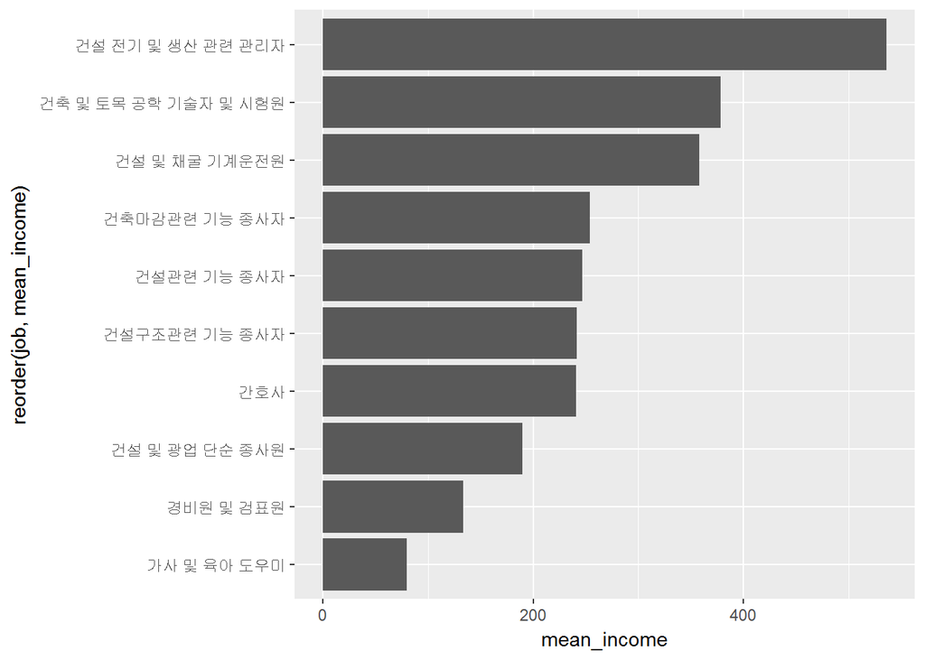

```r
> ggplot(data = top10, aes(x = reorder(job, mean_income),y=mean_income))+
+ geom_col() + coord_flip()
```

```r
> bottom10 <- job_income%>%
+ arrange(mean_income)%>%
+ head(10)
```

마지막으로 그래프를 확인해본다.

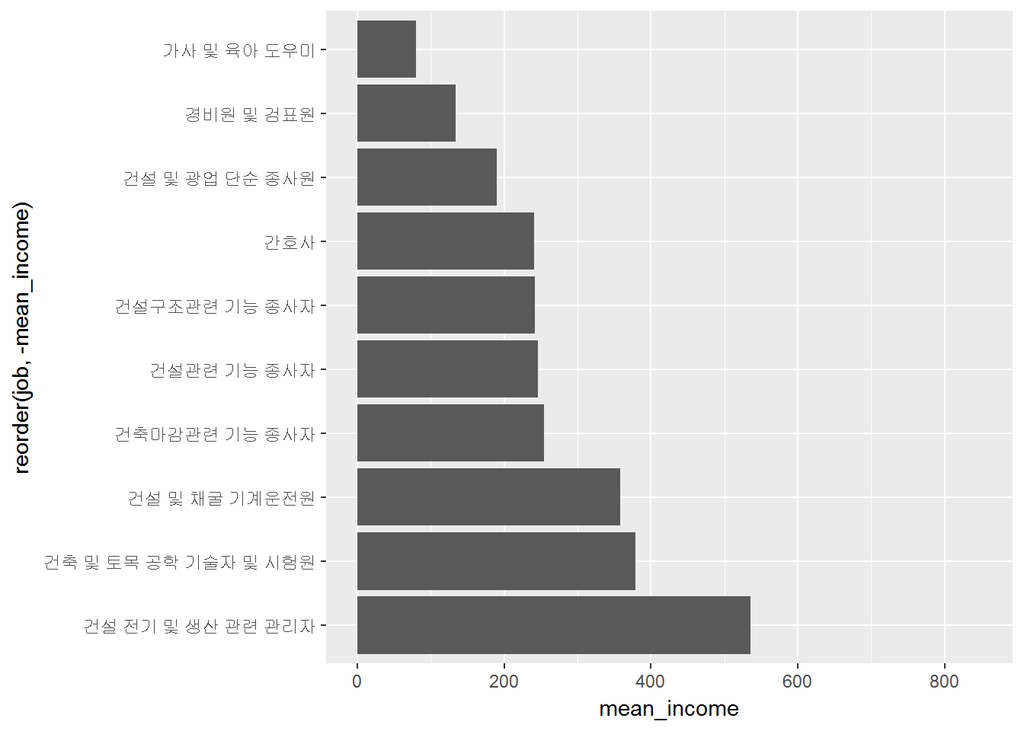

```r
> ggplot(data=bottom10, aes(x=reorder(job,-mean_income), y=mean_income))+
+ geom_col()+
+ coord_flip()+
+ ylim(0,850)
```